# reproducible_research_q2

# After the creation of each figure, I once again use my save_ggplot() function to save the individual species graphs to my figures folder.

# My original question as to whether there was a statistically significant correlation between culmen length and culmen depth was addressed to each of these individual species. For this reason, I thought it would be appropriate to construct a facetting function that could take inputs of other graphs and combine these together to be viewed in one figure. I did this with each of the previously created individual species plots to produce a combined plot that shows the differences in data spread and statistical results.

# Once again I use my save_ggplot function to copy this figure in pdf format to my figures folder.

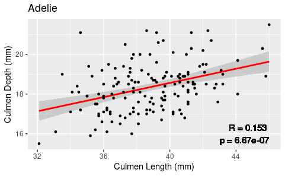

```r
source("functions/illustration.r")


Adelie_plot <- lm_create_scatter_plot(Adelie_dataset, "culmen_length_mm", "culmen_depth_mm",
                    "Adelie",
                    "Culmen Length (mm)", "Culmen Depth (mm)",
                    point_size = 1)
```

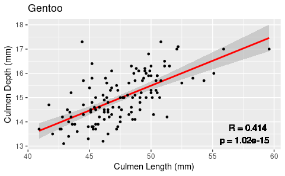

```r
Gentoo_plot <- lm_create_scatter_plot(Gentoo_dataset, "culmen_length_mm", "culmen_depth_mm",
                    "Gentoo",
                    "Culmen Length (mm)", "Culmen Depth (mm)",
                    point_size = 1)
```

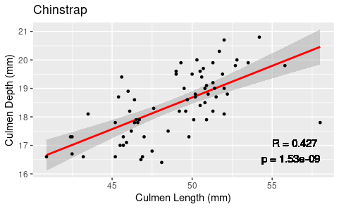

```r
Chinstrap_plot <- lm_create_scatter_plot(Chinstrap_dataset, "culmen_length_mm", "culmen_depth_mm",
                    "Chinstrap",
                    "Culmen Length (mm)", "Culmen Depth (mm)",
                    point_size = 1)
```

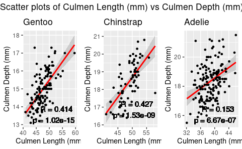

```r
combined_species_plot <- combine_and_facet_plots(list(Gentoo_plot, Chinstrap_plot, Adelie_plot), facet_labels = NULL, "Scatter plots of Culmen Length (mm) vs Culmen Depth (mm) by species")
```

```r
save_ggplot(Adelie_plot, "Adelie_plot.pdf", "figures/")
save_ggplot(Gentoo_plot, "Gentoo_plot.pdf", "figures/")
save_ggplot(Chinstrap_plot, "Chinstrap_plot.pdf", "figures/")
save_ggplot(combined_species_plot, "combined_species_plot.pdf", "figures/")
```

### Results & Discussion

# Starting with the results of the Pearson’s product-moment correlation analyses, it is clear that there is a widely conserved positive correlation between culmen length and culmen depth across all three penguin species. Gentoo (~0.64), Adelie (~0.39) and Chinstrap (~0.65). It is clear however that the strongest correlations were seen in both Gentoo and Chinstrap penguins whereas the Adelie’s is noticeably lower.